# Was the Infection Real? Verifying Tick Infection Status Using Sequencing Data

**Aim:** Some ticks tested positive for *R. africae* infection, but these results needed to be confirmed. Rather than relying on the original test, I checked whether the bacteria’s DNA was genuinely present across the whole reference genome, or whether the signal was coming from just a small, misleading fragment.

**Hypothesis:** Genuinely infected ticks should show even, consistent coverage across the entire *R. africae* genome. Ticks giving a false positive would instead show patchy, uneven coverage, since the signal would only be coming from a small piece of bacterial DNA accidentally integrated into the tick’s own genome, not from a real, whole bacterial infection.

**Approach:** I used the sequencing data already mapped to the *R. africae* genome and broke it into small 1kb windows to measure how consistently the DNA was covered across the whole genome. I then analysed and visualised the results in R to compare infected and uninfected samples.

```r
#Load libraries
knitr::opts_chunk$set(echo=TRUE, message=FALSE, warning=FALSE)
set.seed(1)
suppressPackageStartupMessages({
  library(tidyverse); library(readxl); library(svglite)
})
```

### Data inputs

I loaded the coverage data (how much sequencing data covered each small section of the bacterial genome) along with the sample metadata, then reshaped and combined them so each sample’s coverage values were linked to its infection group.

```r
# Load the coverage matrix and the metadata
coverage_df <- read_excel("r_africae_1kb_coverage.xlsx")
meta_df <- read_excel("meta.xlsx")

# Pivot coverage to "long" format so we can join by sample ID
df_long <- coverage_df %>%
  pivot_longer(cols = -c(chrom, start, end),
               names_to = "IID",
               values_to = "raw_coverage")

# Join with metadata to get the 'Sca12' column (High/Low)
df_combined <- df_long %>%
  left_join(meta_df %>% select(IID, Sca12), by = "IID") %>%
  filter(!is.na(Sca12)) # Remove samples not in metadata
```

### Normalise and calculate statistics

I adjusted each sample’s coverage values so they could be fairly compared to one another, since raw sequencing depth varies between samples. I then calculated the average coverage and variation at each genomic position, separately for the infected and uninfected groups.

```r
# 1. Normalize within each sample by Reads Per Million mapped to the chromosome
df_norm <- df_combined %>%
  group_by(IID) %>%
  mutate(norm_cov = (raw_coverage / sum(raw_coverage)) * 1e6) %>%
  ungroup()

# 2. Calculate Mean and Error (SD) per genomic window per group
plot_data <- df_norm %>%
  group_by(start, Sca12) %>%
  summarise(
    mean_val = mean(norm_cov),
    sd_val = sd(norm_cov),
    .groups = "drop"
  )
```

### Produce the line plot for high (putatively infected) and low (uninfected) groups

I plotted the average coverage across the bacterial genome for both groups, with shading to show the spread of values around that average. This let me visually compare whether infected and uninfected samples showed different coverage patterns.

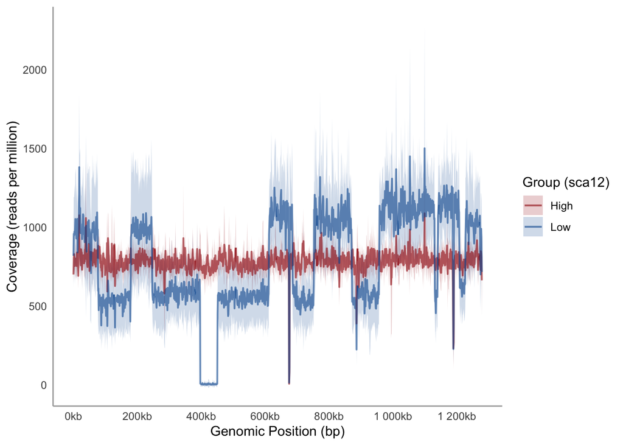

```r
coverage_plot_all <- ggplot(plot_data, aes(x = start, y = mean_val, color = Sca12, fill = Sca12)) +
  # Shaded area for Standard Deviation
  geom_ribbon(aes(ymin = mean_val - sd_val, ymax = mean_val + sd_val),
              alpha = 0.2, color = NA) +
  # Mean line
  geom_line(size = 0.7) +
  scale_color_manual(values = c("High" = "#9e0e0599", "Low" = "#05579e99")) +
  scale_fill_manual(values = c("High" = "#9e0e0599", "Low" = "#05579e99")) +
  theme_minimal() +
  # REMOVE GRID LINES
  theme(
    panel.grid.major = element_blank(), # Removes major grid lines
    panel.grid.minor = element_blank(), # Removes minor grid lines
    axis.line = element_line(color = "darkgrey") # Optional: adds clear x/y axes
  ) +
  scale_x_continuous(
    breaks = seq(0, max(plot_data$start), by = 200000), # Ticks every 200kb
    labels = scales::label_number(scale = 1e-3, suffix = "kb")
    ) +

  labs(
    x = "Genomic Position (bp)",
    y = "Coverage (reads per million)",
    color = "Group (sca12)",
    fill = "Group (sca12)"
  )

coverage_plot_all
```

Legend: Line represents mean Ribbon represents +- 1 standard deviation

### Summary findings

Infected and uninfected ticks showed clearly different coverage patterns across the bacterial genome. This raised a follow-up question: could this difference be explained by something other than infection status, such as where the ticks were collected? I checked this next.

### Check the effect of location on the coverage

To rule out location as an alternative explanation, I split each group (infected and uninfected) by collection site and re-plotted coverage separately. If location was driving the pattern, samples from the same site would cluster together regardless of infection status.

#### Samples in Low group

Among the uninfected samples, coverage patterns were compared across different collection sites to check for a location effect.

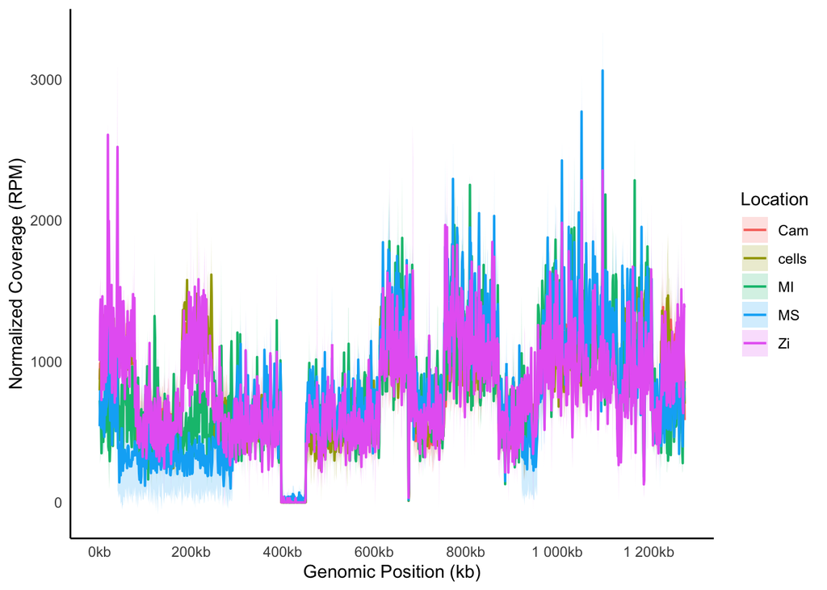

```r
# 1. Filter for Low group and ensure Location is present
low_group_summary <- df_norm %>%
  filter(Sca12 == "Low") %>%
  left_join(meta_df %>% select(IID, Location), by = "IID") %>%
  # 2. Group by Location and genomic window
  group_by(start, Location) %>%
  summarise(
    mean_val = mean(norm_cov),
    sd_val = sd(norm_cov),
    .groups = "drop"
  )

# 3. Plot Mean + SD Ribbon for each Location
ggplot(low_group_summary, aes(x = start, y = mean_val, color = Location, fill = Location)) +
  # Shaded area for variation within each location
  geom_ribbon(aes(ymin = mean_val - sd_val, ymax = mean_val + sd_val),
              alpha = 0.2, color = NA) +
  # Mean line for each location
  geom_line(linewidth = 0.7) +
  theme_minimal() +
  theme(
    panel.grid.major = element_blank(),
    panel.grid.minor = element_blank(),
    axis.line = element_line(color = "black")
  ) +
  labs(
    x = "Genomic Position (kb)",
    y = "Normalized Coverage (RPM)",
    color = "Location",
    fill = "Location"
  ) +
  scale_x_continuous(
    breaks = seq(0, max(low_group_summary$start), by = 200000),
    labels = scales::label_number(scale = 1e-3, suffix = "kb")
  )
```

#### Samples in High group

Among the infected samples, coverage patterns were compared across different collection sites to check for a location effect.

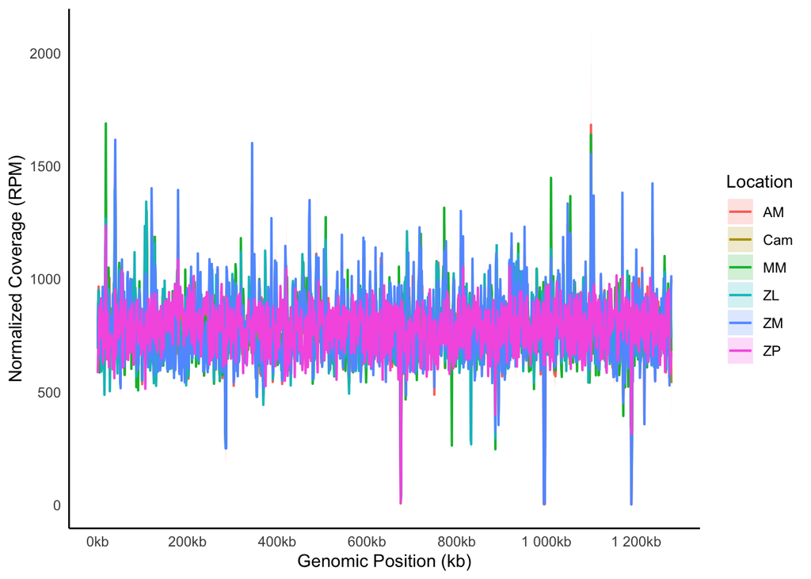

```r
# 1. Filter for High group and ensure Location is present
high_group_summary <- df_norm %>%
  filter(Sca12 == "High") %>%
  left_join(meta_df %>% select(IID, Location), by = "IID") %>%
  # 2. Group by Location and genomic window
  group_by(start, Location) %>%
  summarise(
    mean_val = mean(norm_cov),
    sd_val = sd(norm_cov),
    .groups = "drop"
  )

# 3. Plot Mean + SD Ribbon for each Location (High Group Only)
ggplot(high_group_summary, aes(x = start, y = mean_val, color = Location, fill = Location)) +
  # Shaded area for variation within each location
  geom_ribbon(aes(ymin = mean_val - sd_val, ymax = mean_val + sd_val),
              alpha = 0.2, color = NA) +
  # Mean line for each location
  geom_line(linewidth = 0.7) +
  theme_minimal() +
  theme(
    panel.grid.major = element_blank(),
    panel.grid.minor = element_blank(),
    axis.line = element_line(color = "black")
  ) +
  labs(
    x = "Genomic Position (kb)",
    y = "Normalized Coverage (RPM)",
    color = "Location",
    fill = "Location"
  ) +
  scale_x_continuous(
    breaks = seq(0, max(high_group_summary$start), by = 200000),
    labels = scales::label_number(scale = 1e-3, suffix = "kb")
  )
```

### Summary findings (for high/low separated by location):

Within the infected group, coverage patterns looked similar across collection sites. Within the uninfected group, coverage patterns also looked similar across collection sites. Neither group showed a location-driven pattern.

## Final Conclusion

**Infected and uninfected ticks showed clearly different coverage patterns across the bacterial genome, and this pattern held regardless of where the ticks were collected. This confirmed the coverage difference was driven by genuine infection status, not a hidden effect of location.**